# PEGA for Pine Analysis: Step 2 choose outlier groups

### Group 2 some ideas for null testing

```r
cond <- Group2_logical & results_pine3$gtcontig=="comp60064_c0_seq1"
condnull <- !Group2_logical & results_pine3$gtcontig=="comp60064_c0_seq1"
obs <- cov(results_pine3$Fall_cold_injury_p_raw_rho[cond],results_pine3$LAT_raw_rho[cond])
null1 <- replicate(1000, cov(sample(results_pine3$Fall_cold_injury_p_raw_rho[cond]),sample(results_pine3$LAT_raw_rho[cond])))
hist(null1) # this is centered on 0 but has a wider distribution
getnull <- function(){
  n <- sample(which(condnull), size=49, replace=TRUE)
  cov(results_pine3$Fall_cold_injury_p_raw_rho[n], results_pine3$LAT_raw_rho[n], use="complete.obs")
}
null2 <- replicate(1000, getnull() )
hist(null2)  # has a narrow distribution
```

### Group 3 CMD/MAP RAW outliers

```r
  Group3cols.superdf <- colnames(is.superdf) %in% c("CMD_raw_rho", "MAP_raw_rho")

 ### Dataframe of Group 3
  Group3_allSuperSNPs <- superdf[rowSums(is.superdf[,Group3cols.superdf],na.rm = TRUE)>0,]

  ### Logical Group 3
  Group3_logical <- results_pine3$gcontig__gcontig_pos %in% Group3_allSuperSNPs$gcontig__gcontig_pos
  ## Check these two are equal
  nrow(Group3_allSuperSNPs)
```

```
## [1] 128
```

```r
  sum(Group3_logical)
```

```
## [1] 128
```

```r
  ### Group3 array for boostrap covariance
  Group3_allSuperSNPs_array_names <- unique(Group3_allSuperSNPs$gtcontig)
  Group3_allSuperSNPs_array <- sapply(Group3_allSuperSNPs_array_names, getInd2, Group3_allSuperSNPs)
  length(Group3_allSuperSNPs_array)
```

```
## [1] 34
```

```r
  #snps per contig
  data.frame(contig=Group3_allSuperSNPs_array_names,
             numOutSnps=as.numeric(sapply(Group3_allSuperSNPs_array, length)))
```

```
##               contig numOutSnps
## 1  comp90150_c0_seq1          1
## 2   comp9553_c0_seq1          8
## 3   comp1565_c0_seq1         24
## 4  comp24588_c0_seq1          5
## 5   comp6762_c0_seq1          7
## 6  comp64053_c0_seq1          5
## 7  comp25728_c1_seq1          4
## 8  comp93351_c0_seq1          1
## 9  comp19776_c1_seq1          2
## 10  comp4835_c0_seq1          5
## 11  comp2237_c0_seq1          9
## 12  comp6329_c0_seq1          7
## 13  comp4611_c0_seq1          1
## 14 comp12654_c0_seq1          3
```

[output cut: 20 more lines]

```r
  #34 contigs
```

### Plot Group 3 RAW CMD/MAP

```r
#comp1565_c0_seq1         24
#comp2237_c0_seq1          9
#comp9553_c0_seq1          8

MakeOutlierPlot("Group3_MAP_CMD_EnvByPhenoBayenv1.pdf", Group3_logical , type="Bayenv", envi_ind = envi_ind, pheno_ind=pheno_ind, width=20, height=24,
    Blue_logical=Group3_logical & results_pine3$gtcontig=="comp1565_c0_seq1",
    Green_logical= Group3_logical & results_pine3$gtcontig=="comp2237_c0_seq1",
    Golden_logical=Group3_logical & results_pine3$gtcontig=="comp9553_c0_seq1")


MakeOutlierPlot("Group3_MAP_CMD_EnvByPhenoRaw1.pdf", Group3_logical, type="Raw", envi_ind = envi_ind, pheno_ind=pheno_ind, width=20, height=24, xlim=c(-1,1), ylim=c(-1,1),
    Blue_logical=Group3_logical & results_pine3$gtcontig=="comp1565_c0_seq1",
    Green_logical= Group3_logical & results_pine3$gtcontig=="comp2237_c0_seq1",
    Golden_logical=Group3_logical & results_pine3$gtcontig=="comp9553_c0_seq1")
```

### Compare Group 2 and Group 3

```r
MakeOutlierPlot("Group2_vs_Group3_EnvByPhenoBayenv1.pdf", Group2_logical , type="Bayenv", envi_ind = envi_ind, pheno_ind=pheno_ind, width=20, height=24,
    Blue_logical=Group3_logical)
MakeOutlierPlot("Group2_vs_Group3_EnvByPhenoBayenv_sm.pdf", Group2_logical , type="Bayenv", envi_ind = envi_ind_sm, pheno_ind=pheno_ind_sm, width=10, height=12,
    Blue_logical=Group3_logical)

MakeOutlierPlot("Group2_vs_Group3_EnvByPhenoRaw1.pdf", Group2_logical, type="Raw", envi_ind = envi_ind, pheno_ind=pheno_ind, width=20, height=24, xlim=c(-1,1), ylim=c(-1,1),
    Blue_logical=Group3_logical)
MakeOutlierPlot("Group2_vs_Group3_EnvByPhenoRaw1_sm.pdf", Group2_logical, type="Raw", envi_ind = envi_ind_sm, pheno_ind=pheno_ind_sm, width=10, height=12, xlim=c(-1,1), ylim=c(-1,1),
    Blue_logical=Group3_logical)

MakeOutlierPlot("Group1sm_EnvByPhenoBayenv1.pdf", Group1_logical , type="Bayenv", envi_ind = envi_ind_sm, pheno_ind=pheno_ind_sm, width=10, height=12)

MakeOutlierPlot("Group1sm_EnvByPhenoRaw1.pdf", Group1_logical, type="Raw", envi_ind = envi_ind_sm, pheno_ind=pheno_ind_sm, width=10, height=12, xlim=c(-1,1), ylim=c(-1,1))
```

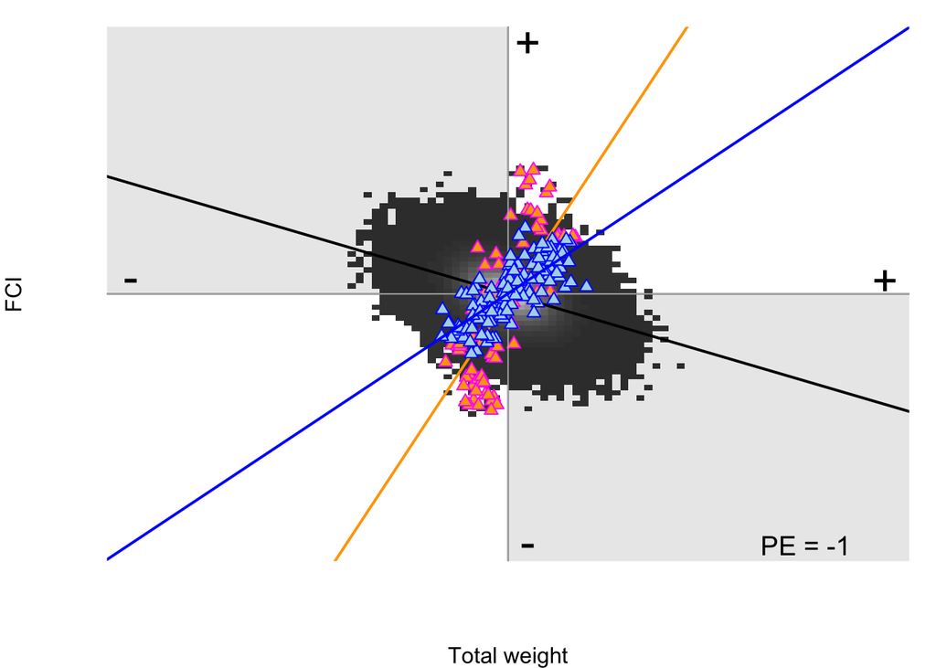

```r
x=results_pine3$root_wt_shoot_wt_1_rhoave_BAYENV
  # Total weight (ratio is without 1)
y=results_pine3$Fall_cold_injury_rhoave_BAYENV
par(mar=c(4,4,1,1))
plot_2D.b(x,y,xlab="Total weight", ylab="FCI",
                      xlim=c(-0.3,0.3),
                      ylim=c(-0.3,0.3),
                      nbin=100,
                      x_sub=x[Group2_logical],
                      y_sub=y[Group2_logical],
                      x_sub_blue=x[Group3_logical],
                      y_sub_blue=y[Group3_logical],
                      PE=-1)
```

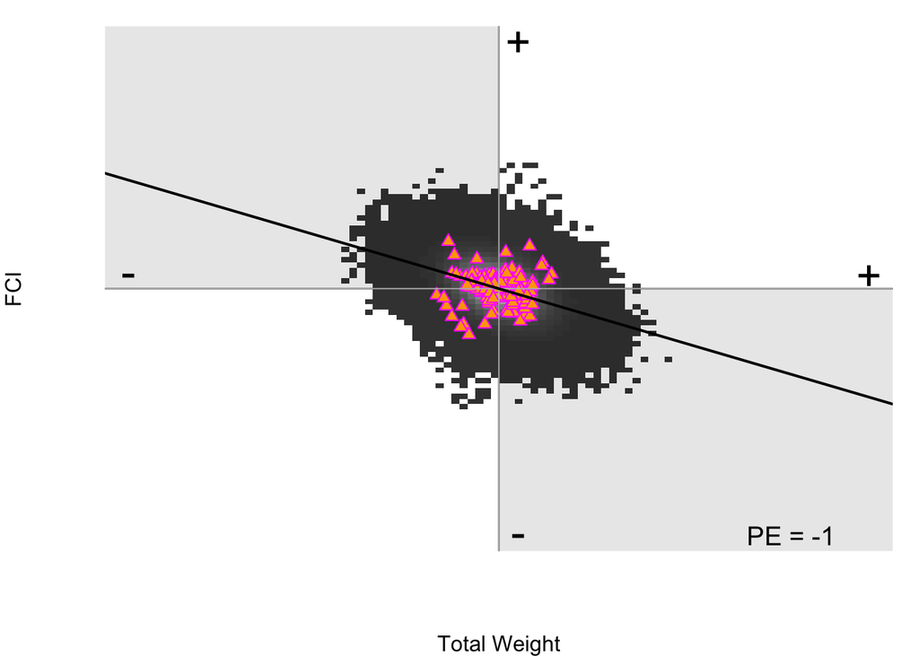

```r
# other outliers that aren't in the two groups
plot_2D.b(x,y,xlab="Total Weight", ylab="FCI",
                      xlim=c(-0.3,0.3),
                      ylim=c(-0.3,0.3),
                      nbin=100,
                      x_sub=x[Group1_logical & !Group2_logical & !Group3_logical],
                      y_sub=y[Group1_logical & !Group2_logical & !Group3_logical],
                      PE=-1)
```

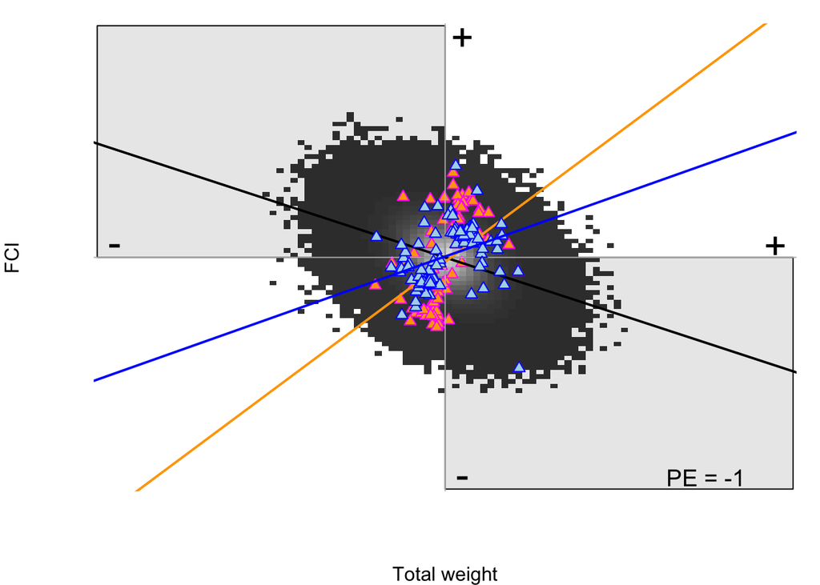

```r
x=results_pine3$root_wt_shoot_wt_p_1_raw_rho
y=results_pine3$Fall_cold_injury_p_raw_rho
plot_2D.b(x,y,xlab="Total weight", ylab="FCI",
                      xlim=c(-1,1),
                      ylim=c(-1,1),
                      nbin=100,
                      x_sub=x[Group2_logical],
                      y_sub=y[Group2_logical],
                      x_sub_blue=x[Group3_logical],
                      y_sub_blue=y[Group3_logical],
                      PE=-1)
```

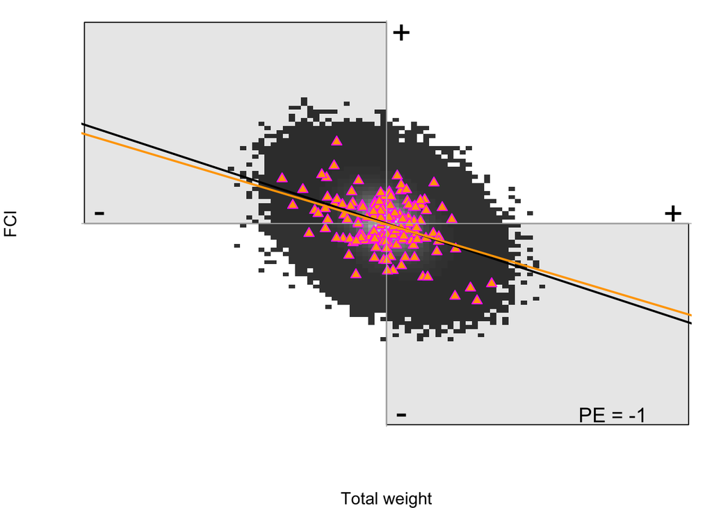

```r
plot_2D.b(x,y,xlab="Total weight", ylab="FCI",
                      xlim=c(-1,1),
                      ylim=c(-1,1),
                      nbin=100,
                      x_sub=x[Group1_logical & !Group2_logical & !Group3_logical],
                      y_sub=y[Group1_logical & !Group2_logical & !Group3_logical],
                      PE=-1)
```

### Make outlier plots - one for each candidate gene

```r
 ### Loop through top genes but for subset of envi
  for (i in 1:length(topcan)){
    magLogical <- results_pine3$gtcontig==topcan[i] & Group1_logical #outlier SNPs
    blueLogical <- results_pine3$gtcontig==topcan[i] & !Group1_logical #other SNPs in the gene
    nameBay <- paste(round(G1_df$prop[G1_df$contig==topcan[i]],2),
                     G1_df$numOutSnps[G1_df$contig==topcan[i]],
                     G1_df$numTotSnps[G1_df$contig==topcan[i]],
                     topcan[i], "BayenvSub.pdf", sep="_")
    nameRaw <- paste(round(G1_df$prop[G1_df$contig==topcan[i]],2),
                     G1_df$numOutSnps[G1_df$contig==topcan[i]],
                     G1_df$numTotSnps[G1_df$contig==topcan[i]],
                     topcan[i], "RawSub.pdf", sep="_")
    MakeOutlierPlot(nameBay, magLogical, type="Bayenv", Blue_logical = blueLogical,envi_ind = envi_ind_sm, pheno_ind=pheno_ind_sm, width=10, height=12)
    MakeOutlierPlot(nameRaw, magLogical, type="Raw", Blue_logical = blueLogical, xlim=c(-1,1), ylim=c(-1,1), envi_ind = envi_ind_sm, pheno_ind=pheno_ind_sm, width=10, height=12)
    print(c("done with", i, "of", length(topcan)))
  } #end for loop
```

### Make a table for annotations

```r
head(G1_df)
```

```
##               contig numOutSnps numTotSnps        prop
## 40  comp8905_c0_seq1          1        152 0.006578947
## 38 comp50550_c0_seq1          1        140 0.007142857
## 88   comp332_c0_seq1          1        116 0.008620690
## 68  comp1878_c0_seq1          1        107 0.009345794
## 47 comp11553_c0_seq1          1        100 0.010000000
## 53 comp27756_c0_seq1          1         88 0.011363636
```

```r
nrow(G1_df)
```

```
## [1] 107
```

```r
G1_df$TempGroup <- G1_df$contig %in% Group2_allSuperSNPs_array_names
G1_df$PrecipGroup <- G1_df$contig %in% Group3_allSuperSNPs_array_names
G1_df$BothTempPrecip <- G1_df$PrecipGroup & G1_df$TempGroup
G1_df$SpruceOrthoOut <- G1_df$contig %in% results_pine3$gtcontig[results_pine3$pine_super_convergent]
G1_df
```

```
##                 contig numOutSnps numTotSnps        prop TempGroup
## 40    comp8905_c0_seq1          1        152 0.006578947     FALSE
## 38   comp50550_c0_seq1          1        140 0.007142857     FALSE
## 88     comp332_c0_seq1          1        116 0.008620690     FALSE
## 68    comp1878_c0_seq1          1        107 0.009345794     FALSE
## 47   comp11553_c0_seq1          1        100 0.010000000     FALSE
## 53   comp27756_c0_seq1          1         88 0.011363636     FALSE
## 18    comp1063_c0_seq1          1         87 0.011494253     FALSE
## 9     comp3733_c0_seq1          1         85 0.011764706     FALSE
## 10   comp13145_c1_seq1          1         85 0.011764706      TRUE
## 48   comp45093_c0_seq1          1         82 0.012195122     FALSE
## 11   comp13672_c0_seq1          1         72 0.013888889     FALSE
## 93    comp7699_c0_seq1          1         66 0.015151515     FALSE
## 91    comp3324_c0_seq1          1         61 0.016393443     FALSE
## 13    comp2016_c0_seq1          1         58 0.017241379     FALSE
```

[output cut: 201 more lines]

```r
write.table(G1_df, "../PineTopCandidates.txt", col.names=TRUE, row.names=FALSE)
G1_df

### save outlier status
save(Group1_logical,Group2_logical,Group3_logical, file = "../data/large_files/Pine_Alpha_AveRho_WithSuperLogical_TOPCANIDATE_logicals.Rdata")
```

### Overview:

- took Sam’s list of super outliers - genes that have more outlier snps than predicted by random based on raw or corrected correlations at p9 level
- reduced list further to genes with SNPs in > 0.999 on raw rho (Group 1)
- I noticed two groups of behavior. Chose variables that had strongest PE associations.
- Group temp: subset of Group 1 that are raw outliers in lat and DD0
- Group moisture: subset of Group 1 that are raw outliers in MAP and CMD

Red genes (LAT and DD0) Blue genes (MAP and CMD) in Bayenv2: * Both read and blue decrease FWCI with latitude and DD0 (true in raw) * Both decrease height and MGR with DD0 (true in raw) * Red decrease FWCI with elevation, while blue increase FWCI with elevation (true in raw for WCI in elevation) * Red increase FWSCI, MGR, height, and diam with MAP, while blue do the opposite (true for raw) * red increase FWCI, MCG, height, and diam with FFP, while blue do the opposite (in raw associations blue do nothing) * red and blue increase FWCI with CMD, and increase height and diam